# Business Churn Prediction

Cole Lifer, Richard Garbett, Jordan Harmer

4/13/23

## Introduction

Restaurants, fast food establishments, and other dining areas that allow for quick access to fountain soda provide a ripe landscape for Swire Coca-Cola’s B2B revenue streams. However, Swire Coca-Cola can’t simply provide machinery to whoever wants it. It needs to be a profitable investment for them as well. Typically, these results are measured over a 3-year sales volume for each establishment. The main success predictors of a Swire Coca-Cola’s customer are popularity, longevity, and total sales volume. Therefore, how can they make a more informed decision to provide a machine or not? The answer: Prediction. Realistically, Swire Coca-Cola would be able to use the predicted data to offer more competitive prices to interested customers. This could minimize their risk since a predictive model may be able to produce quality error metrics. Overall, customer retention and profitability would mutually beneficial for both involved parties.

An analytical approach could be taken for this problem that involves building a series of models and testing each of them individually with a wide range of test and train data. Included within this data would be valuable predictors such as historical sales data, consumer reviews, and location (and other census) data. We would seek to successfully predict outcome variables such as Customer Age (Longevity), Total Sales Volume, and Consumer Ratings.

This project’s scope would include the initial building and testing of multiple models to predict the longevity, popularity, and total 3-year sales volume of a potential customer. After this initial phase, the final models will be chosen and tweaked to provide the best error metrics possible before using it in production.

Questions to guide exploration:

Average customer length? Are customers similar in shared markets? Are shared markets segmented by customer type? What does the performance of customer types look like in general? How should we predict popularity without Restaurant Ratings available in the dataset? Zip Code? Geolocation? Most likely total sales. How do older customers compare to newer ones?

```r
knitr::opts_chunk$set(echo = TRUE)
library(prettydoc)
library(ggplot2)
library(tidyverse)
library(scales)
library(caret)
library(MASS)
library(arm)
library(gridExtra)
library(knitr)
library(kableExtra)
library(knitr)
library(dplyr)
library(e1071)
library(psych)
library(C50)
library(rminer)
library(rmarkdown)
library(matrixStats)
library(rpart)
#install.packages("rpart.plot")
library(rpart.plot)
#install.packages("rJava")
library(rJava)
#install.packages("RWeka")
library(RWeka)
library(plotROC)
library(car)
library(tidymodels)
library(xgboost)
library(corrplot)
library(vip)
library(DALEXtra)
library(dataPreparation)
library(themis)
library(ranger)
library(kernlab)
#timing
library(tictoc)

tic()

## Importing both files and combining for EDA

CustData <- read.csv("FSOP_Customer_Data_v2.0 edited.csv")
SalesData <- read.csv("FSOP_Sales_Data_v2.0.csv")


## Combining Data
#full_data <- rbind(SalesData, CustData)


## Creating variable for cleaned training data to reference in our models

#clean_train <- full_data %>%
 #na.omit(full_data)
```

### Basic Viewing

Creating new variable for customer length, removing outliers, etc.

```r
## Head

head(SalesData)
```

```
##   CUSTOMER_NUMBER_BLINDED PRODUCT_SOLD_BLINDED             BEV_CAT_DESC
## 1       C0051046109640797        M056203880974           CORE SPARKLING
## 2       C0348074302380406        M042308250090           CORE SPARKLING
## 3       C0277089703710223        M010605530774                      TEA
## 4       C0112072503650635        M050800200648            ENERGY DRINKS
## 5       C0305009008200279        M009608400345           CORE SPARKLING
## 6       C0095084905960864        M000802070510 ENHANCED WATER BEVERAGES
##   CALORIE_CAT_DESC           PACK_TYPE_DESC PACK_SIZE_SALES_UNIT_DESCRIPTION
## 1  REGULAR CALORIE Plastic Bottle - Contour                    20 OZ 1-Ls 24
## 2      LOW CALORIE     Aluminum Can - Sleek                    12 OZ 4-Pk 24
## 3      LOW CALORIE   Plastic Bottle - Other                  18.5 OZ 1-Ls 12
## 4  REGULAR CALORIE             Aluminum Can                    16 OZ 1-Ls 24
## 5  REGULAR CALORIE  Plastic Bottle - Dimple                     2 LTR 1-Ls 8
## 6      LOW CALORIE   Plastic Bottle - Other                  23.7 OZ 1-Ls 12
##   PHYSICAL_VOLUME DISCOUNT INVOICE_PRICE DEAD_NET GROSS_PROFIT_DEAD_NET    COGS
## 1              88  2246.40       2505.60  1924.70               1112.73  682.41
## 2              58  1197.12       1666.92  1468.77                316.19 1185.98
## 3             108  3429.00       1755.00  1499.03                403.25 1107.73
## 4              15   307.12        592.88   553.18                 77.90  475.28
## 5             195  3382.05       2077.95  1812.90                661.21 1416.99
## 6               0     0.00          0.00     8.68                  4.85    0.00
##   MIN_POSTING_DATE MAX_POSTING_DATE NUM_OF_TRANSACTIONS
## 1        1/12/2021       12/30/2022                 157
## 2         2/2/2021       12/30/2022                  40
## 3         3/7/2022       12/30/2022                  62
## 4         6/9/2022       12/30/2022                  17
## 5         1/5/2021       12/30/2022                 166
## 6         8/4/2021         9/7/2021                   5
```

```r
head(CustData)
```

```
##   CUSTOMER_NUMBER_BLINDED SALES_OFFICE_DESCRIPTION DELIVERY_PLANT_DESCRIPTION
## 1       C0895044502170683               Tucson, AZ                 Tucson, AZ
## 2       C0409008701210025               Tacoma, WA    Tacoma Sales Center, WA
## 3       C0278065006510168          Walla Walla, WA            Walla Walla, WA
## 4       C0559043803480412             Prescott, AZ               Glendale, AZ
## 5       C0729091103720749                 Reno, NV                   Reno, NV
## 6       C0291037806480104          Albuquerque, NM            Albuquerque, NM
##   ON_BOARDING_DATE     ADDRESS_CITY ADDRESS_ZIP_CODE      COUNTY GEO_LONGITUDE
## 1         2/6/2017           TUCSON            85756        PIMA     -110.9284
## 2        5/11/2009       FORT LEWIS            98433      PIERCE     -122.5872
## 3        2/18/2004    COLLEGE PLACE            99324 WALLA WALLA     -118.3730
## 4         9/3/1993         PRESCOTT            86301     YAVAPAI     -112.4505
## 5       12/17/2014 SOUTH LAKE TAHOE            96150   EL DORADO     -119.9842
## 6        6/17/2004      ALBUQUERQUE            87123  BERNALILLO     -106.5299
##   GEO_LATITUDE CUSTOMER_ACTIVITY_CLUSTER_DESCRIPTION
```

[output cut: 27 more lines]

```r
# Summaries

#summary(SalesData)
#summary(CustData)

#na.omit(SalesData)
#na.omit(CustData)
```

### Variable Creation

```r
New_Cust <- CustData %>%
    mutate(New_Onboard = as.Date(ON_BOARDING_DATE, "%m/%d/%Y"),
      Pulled_Date = as.Date("2023-02-11"),
      Cust_Age_Yrs = round(as.numeric((difftime(Pulled_Date, New_Onboard, units = "days"))/365),digits = 4))

sum(is.na(New_Cust$ON_BOARDING_DATE))
```

```
## [1] 0
```

```r
sum(is.na(New_Cust$Pulled_Date))
```

```
## [1] 0
```

```r
#No NA's so looking for values greater than pulled date (they can't exist)
sum(New_Cust$ON_BOARDING_DATE >= "2023-02-19")
```

```
## [1] 25232
```

```r
head(New_Cust)
```

```
##   CUSTOMER_NUMBER_BLINDED SALES_OFFICE_DESCRIPTION DELIVERY_PLANT_DESCRIPTION
## 1       C0895044502170683               Tucson, AZ                 Tucson, AZ
## 2       C0409008701210025               Tacoma, WA    Tacoma Sales Center, WA
## 3       C0278065006510168          Walla Walla, WA            Walla Walla, WA
## 4       C0559043803480412             Prescott, AZ               Glendale, AZ
## 5       C0729091103720749                 Reno, NV                   Reno, NV
## 6       C0291037806480104          Albuquerque, NM            Albuquerque, NM
##   ON_BOARDING_DATE     ADDRESS_CITY ADDRESS_ZIP_CODE      COUNTY GEO_LONGITUDE
## 1         2/6/2017           TUCSON            85756        PIMA     -110.9284
## 2        5/11/2009       FORT LEWIS            98433      PIERCE     -122.5872
## 3        2/18/2004    COLLEGE PLACE            99324 WALLA WALLA     -118.3730
## 4         9/3/1993         PRESCOTT            86301     YAVAPAI     -112.4505
## 5       12/17/2014 SOUTH LAKE TAHOE            96150   EL DORADO     -119.9842
## 6        6/17/2004      ALBUQUERQUE            87123  BERNALILLO     -106.5299
##   GEO_LATITUDE CUSTOMER_ACTIVITY_CLUSTER_DESCRIPTION
```

[output cut: 34 more lines]

```r
#max(New_Cust$Cust_Age_Yrs)

#checking
min(New_Cust$Cust_Age_Yrs)
```

```
## [1] -7982.184
```

```r
#locating outlier row
New_Cust[which.min(New_Cust$Cust_Age_Yrs),]
```

```
##       CUSTOMER_NUMBER_BLINDED SALES_OFFICE_DESCRIPTION
## 13819       C0173058906290124               Draper, UT
##       DELIVERY_PLANT_DESCRIPTION ON_BOARDING_DATE ADDRESS_CITY ADDRESS_ZIP_CODE
## 13819                 Draper, UT       12/31/9999   WHITESTONE            11357
##       COUNTY GEO_LONGITUDE GEO_LATITUDE CUSTOMER_ACTIVITY_CLUSTER_DESCRIPTION
## 13819 QUEENS             0            0                  Third Party (Non-Con
##       CUSTOMER_TRADE_CHANNEL_DESCRIPTION CUSTOMER_SUB_TRADE_CHANNEL_DESCRIPTION
## 13819                          Wholesale                                Bottler
##       BUSINESS_TYPE_EXTENSION_DESCRIPTION CUSTOMER_TRADE_CHANNEL_DESCRIPTION2
## 13819                    Return To Vendor                           Wholesale
##       MARKET_DESCRIPTION COLD_DRINK_CHANNEL_DESCRIPTION New_Onboard Pulled_Date
## 13819       SUPPLY CHAIN                      WHOLESALE  9999-12-31  2023-02-11
##       Cust_Age_Yrs
## 13819    -7982.184
```

```r
#removing outlier
New_Cust <- New_Cust[-13819,]

#rechecking
New_Cust[which.min(New_Cust$Cust_Age_Yrs),]
```

```
##       CUSTOMER_NUMBER_BLINDED SALES_OFFICE_DESCRIPTION
## 23835       C0809026104670251       Grand Junction, CO
##       DELIVERY_PLANT_DESCRIPTION ON_BOARDING_DATE   ADDRESS_CITY
## 23835         Grand Junction, CO       12/21/2022 GRAND JUNCTION
##       ADDRESS_ZIP_CODE COUNTY GEO_LONGITUDE GEO_LATITUDE
## 23835            81505   MESA      -108.588      39.0827
##       CUSTOMER_ACTIVITY_CLUSTER_DESCRIPTION CUSTOMER_TRADE_CHANNEL_DESCRIPTION
## 23835                     Eating & Drinking               Quick Service Restau
##       CUSTOMER_SUB_TRADE_CHANNEL_DESCRIPTION
## 23835                    QSR-Other Fast Food
##       BUSINESS_TYPE_EXTENSION_DESCRIPTION CUSTOMER_TRADE_CHANNEL_DESCRIPTION2
## 23835                                 DSD                Quick Service Restau
##       MARKET_DESCRIPTION COLD_DRINK_CHANNEL_DESCRIPTION New_Onboard Pulled_Date
## 23835               FSOP                EATING/DRINKING  2022-12-21  2023-02-11
##       Cust_Age_Yrs
## 23835       0.1425
```

## Exploratory Data Analysis

### Counties by Customer Age

Seems to be wide variation among counties. We will dig in further at a later time; however, this is great intel for now.

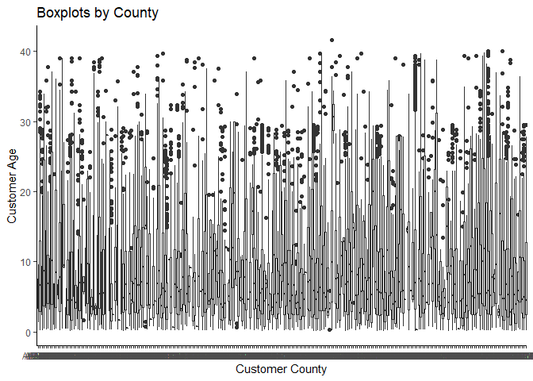

```r
## boxplots by county

county_plot <-
ggplot(data = New_Cust, aes(x = COUNTY, y = Cust_Age_Yrs)) +
  geom_boxplot() +
  theme_classic() +
  labs(x='Customer County',y='Customer Age',title='Boxplots by County')

county_plot
```

### Average Customer Age

Should have a wide base of train & test data if average customer length is over 8.7 years.

```
## [1] 8.795476
```

### Customer Segments

Average customer age varies widely by trade channel.

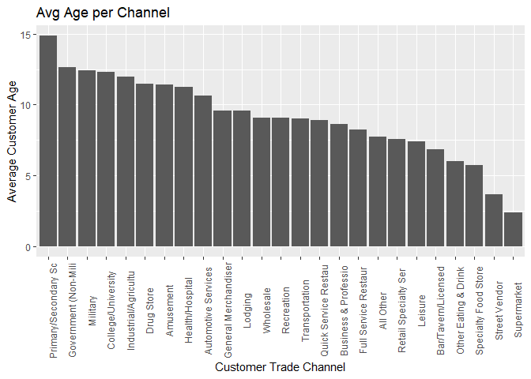

```r
Seg_plot <-
ggplot(data = New_Cust, aes(x = reorder(factor(CUSTOMER_TRADE_CHANNEL_DESCRIPTION), -Cust_Age_Yrs), y = Cust_Age_Yrs)) +
  geom_bar(stat = "summary", fun = "mean") +
  theme(axis.text.x = element_text(angle = 90)) +
  labs(x='Customer Trade Channel',y='Average Customer Age',title='Avg Age per Channel')


Seg_plot
```

## Sales Data Analysis

There’s a large range of invoice totals. Could possibly be segmented by City, State, Neighborhood, etc?

```
## # A tibble: 40,390 × 2
##    CUSTOMER_NUMBER_BLINDED   max
##    <chr>                   <dbl>
##  1 C0001004007230617          0
##  2 C0001004306830869          0
##  3 C0001005009010198        420.
##  4 C0001006902500643       1550.
##  5 C0001007600510372        878.
##  6 C0001009805140924       9054.
##  7 C0001013303170784       1320.
##  8 C0001015409730162        113.
##  9 C0001016607790093       9358.
## 10 C0001018506720242        476.
## # … with 40,380 more rows
```

### Invoice Amounts

There’s a large distinction in each customer’s largest invoices

```
## [1] 1813004
```

```
## [1] -90.95
```

### Transactions per Customer

There’s a wide range of outcomes here. This will be good to dig into.

```r
test_sales2 <-
SalesData %>%
  group_by(CUSTOMER_NUMBER_BLINDED) %>%
  summarise(max = max(NUM_OF_TRANSACTIONS, na.rm=TRUE))

test_sales2
```

```
## # A tibble: 40,390 × 2
##    CUSTOMER_NUMBER_BLINDED   max
##    <chr>                   <int>
##  1 C0001004007230617           2
##  2 C0001004306830869           1
##  3 C0001005009010198          14
##  4 C0001006902500643          70
##  5 C0001007600510372          12
##  6 C0001009805140924          86
##  7 C0001013303170784          15
##  8 C0001015409730162           8
##  9 C0001016607790093          41
## 10 C0001018506720242           6
## # … with 40,380 more rows
```

### Max & Min Trans p/Customer

There’s a wide range of outcomes here. This will be good to dig into. Certain customers must be with Swire much longer.

```r
#max and mins

print(max(test_sales2$max))
```

```
## [1] 468
```

```r
print(min(test_sales2$max))
```

```
## [1] 1
```

### Beverage Categories

Perhaps, certain beverage categories have a better GP. After creating the plot, that seems obvious.

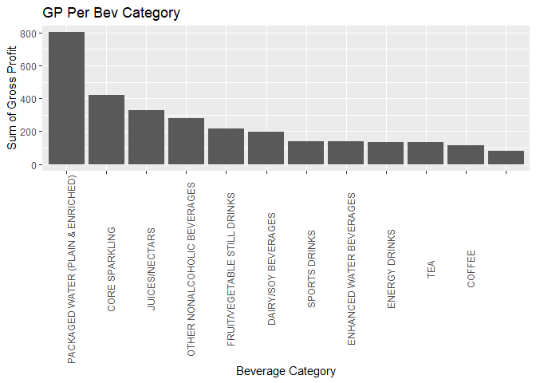

```r
## plot of beverage category by GP

bev_plot <-
ggplot(data = SalesData, aes(x = reorder(factor(BEV_CAT_DESC), -GROSS_PROFIT_DEAD_NET), y = GROSS_PROFIT_DEAD_NET)) +
  geom_histogram(stat = "summary") +
  theme(axis.text.x = element_text(angle = 90)) +
  labs(x='Beverage Category',y='Sum of Gross Profit',title='GP Per Bev Category')

bev_plot
```

# Results of EDA

There are several issues with this data. There are incorrect dates, negative invoice amounts, and several other clear issues that will need to be thoroughly investigated and cleaned before we can accurately start modeling based off of it. I do believe I’ve made good steps towards identifying areas of interests when building my predictive model. Certain Beverage Categories seem to be much more lucrative, certain neighborhoods and cities seem to have much more customer success, and certain subsets of customers seem to order higher total invoice amounts. My EDA has immediately made me far more weary of the data first and foremost. It will need a lot of cleaning before we can trust it. However, I was able to see some good relationships amongst categories and outcome variables such as customer age (length), and gross profit. I don’t have any ethical considerations yet. However, I’m also not 100% sure how we are supposed to predict consumer reviews without any real-life data whatsoever. I will need to research more. Once I have more information about the consumer reviews, ethical considerations may arise at that time. Up to this point, I haven’t done any web scraping, etc.

# Modeling

## Further Data Preparation

We have two main objectives here: To predict the longevity of a Swire Coca-Cola customer and also predict the total 3-year sales volume of new Swire customers. To predict the customer length, we need to create a new variable by determining their last purchase date and then subtract that from their onboarding date. This will become our outcome variable. To predict 3-year sales volume, we can produce total revenue over the two year period per customer and then extrapolate that over a three year period. After this, we can use this outcome variable.

For the three-year sales volume, this will be a continuous outcome variable which means we have many possible models we could test. I believe a Neural Network, SVM, or some type of Linear/Logistic Regression could perform quite well.

For the customer length prediction, this is a categorical outcome variable. 1, 2, or 3+ years. Since we have buckets, a Decision Tree, SVM, or Naive Bayes Classifier could all be good options here. I believe Naive Bayes could perform quite well considering we have a multi-class classification problem and the nature of the input variables are mostly categorical.

```r
# Realized previous customer age variable in CustData wasn't correct. We need to take the max of max posting date and subtract from onboarding date

# Converting Sales Data dates to date format

SalesData <- SalesData %>%
    mutate(cust_start_date = as.Date(MIN_POSTING_DATE, format = "%m/%d/%Y"),
           cust_end_date = as.Date(MAX_POSTING_DATE,format = "%m/%d/%Y"))

#head(SalesData)

# Finding max of max posting date for all customers

custmaxtrans <- aggregate(cust_end_date ~ CUSTOMER_NUMBER_BLINDED, SalesData , max)

#head
#head(custmaxtrans)

New_Cust1 <- New_Cust[,-18:-19]
New_Cust1 <- merge(New_Cust1, custmaxtrans , by="CUSTOMER_NUMBER_BLINDED")

# Creating new customer age variable

New_Cust2 <- New_Cust1 %>%
    mutate(Cust_Age_Yrs = round(as.numeric((difftime(cust_end_date, New_Onboard, units = "days"))/365),digits = 4))

#Bucketing

within(New_Cust2, New_Cust2$Cust_Age_Bucket <- ifelse(Cust_Age_Yrs < 2, 1,
                        ifelse(Cust_Age_Yrs < 3 & Cust_Age_Yrs > 2 , 2,
                               ifelse(Cust_Age_Yrs > 3 , 3 ,NA))) )

# Creating a new column called Age_Group

New_Cust2$Age_Group <- ifelse(New_Cust2$Cust_Age_Yrs < 2, 1, ifelse(New_Cust2$Cust_Age_Yrs >= 2 & New_Cust2$Cust_Age_Yrs <= 3, 2, 3))

max(New_Cust2$Age_Group)
min(New_Cust2$Age_Group)

New_Cust2 <- New_Cust2 %>%
  mutate(
    Age_Group = factor(Age_Group, levels = c("1", "2", "3"))
  )

#Factoring other variables

New_Cust2 <- New_Cust2 %>%
  mutate(
    SALES_OFFICE_DESCRIPTION = factor(SALES_OFFICE_DESCRIPTION),
    DELIVERY_PLANT_DESCRIPTION = factor(DELIVERY_PLANT_DESCRIPTION),
    CUSTOMER_ACTIVITY_CLUSTER_DESCRIPTION = factor(CUSTOMER_ACTIVITY_CLUSTER_DESCRIPTION),
    CUSTOMER_TRADE_CHANNEL_DESCRIPTION = factor(CUSTOMER_TRADE_CHANNEL_DESCRIPTION),
    CUSTOMER_SUB_TRADE_CHANNEL_DESCRIPTION = factor(CUSTOMER_SUB_TRADE_CHANNEL_DESCRIPTION),
    BUSINESS_TYPE_EXTENSION_DESCRIPTION = factor(BUSINESS_TYPE_EXTENSION_DESCRIPTION),
    CUSTOMER_TRADE_CHANNEL_DESCRIPTION2 = factor(CUSTOMER_TRADE_CHANNEL_DESCRIPTION2),
    MARKET_DESCRIPTION = factor(MARKET_DESCRIPTION),
    COLD_DRINK_CHANNEL_DESCRIPTION = factor(COLD_DRINK_CHANNEL_DESCRIPTION),
    ADDRESS_CITY = factor(ADDRESS_CITY),
    COUNTY = factor(COUNTY),
    ADDRESS_ZIP_CODE = as.numeric(ADDRESS_ZIP_CODE),

  )


#test

# Calculate the chi-squared statistic for all pairs of categorical variables
chi_squared <- sapply(New_Cust2[, sapply(New_Cust2, is.factor)], function(x) sapply(New_Cust2[, sapply(New_Cust2, is.factor)], function(y) chisq.test(table(x, y))$statistic))

# Extract the chi-squared values with the target variable
chi_squared_with_target <- chi_squared[,"Age_Group"]

# Sort the chi-squared values in descending order
sorted_chi_squared <- sort(chi_squared_with_target, decreasing = TRUE)

# Print the sorted chi-squared values
print(sorted_chi_squared)

# Select the top k variables based on the chi-squared values
k <- 5
selected_vars <- names(sorted_chi_squared)[1:k]

#levels

levels(New_Cust2$COLD_DRINK_CHANNEL_DESCRIPTION)
```

## Splitting Data

```r
#Checking for NA's in Dataset

colSums(is.na(New_Cust2))
```

```
##                CUSTOMER_NUMBER_BLINDED               SALES_OFFICE_DESCRIPTION
##                                      0                                      0
##             DELIVERY_PLANT_DESCRIPTION                       ON_BOARDING_DATE
##                                      0                                      0
##                           ADDRESS_CITY                       ADDRESS_ZIP_CODE
##                                      0                                      0
##                                 COUNTY                          GEO_LONGITUDE
##                                      0                                      0
##                           GEO_LATITUDE  CUSTOMER_ACTIVITY_CLUSTER_DESCRIPTION
##                                      0                                      0
##     CUSTOMER_TRADE_CHANNEL_DESCRIPTION CUSTOMER_SUB_TRADE_CHANNEL_DESCRIPTION
##                                      0                                      0
##    BUSINESS_TYPE_EXTENSION_DESCRIPTION    CUSTOMER_TRADE_CHANNEL_DESCRIPTION2
##                                      0                                      0
##                     MARKET_DESCRIPTION         COLD_DRINK_CHANNEL_DESCRIPTION
##                                      0                                      0
##                            New_Onboard                          cust_end_date
##                                      0                                      0
##                           Cust_Age_Yrs                              Age_Group
##                                      0                                      0
```

```r
New_Cust2 <- New_Cust2[!(is.na(New_Cust2$COUNTY) | New_Cust2$COUNTY==""), ]

#Using chi-squared and other methods to reduce noise

Cust_Model_Set <- New_Cust2[,!names(New_Cust2) %in% c("CUSTOMER_NUMBER_BLINDED","ON_BOARDING_DATE","New_Onboard", "cust_end_date", "Cust_Age_Yrs", "GEO_LONGITUDE", "GEO_LATITUDE", "DELIVERY_PLANT_DESCRIPTION", "SALES_OFFICE_DESCRIPTION", "MARKET_DESCRIPTION", "COLD_DRINK_CHANNEL_DESCRIPTION","CUSTOMER_ACTIVITY_CLUSTER_DESCRIPTION")]


# test for kicks and giggles
#New_Custtest <- New_Cust2[,17:20]

# Splitting Customer Data into Train and Test

set.seed(123)
LETSTrain <- createDataPartition(Cust_Model_Set$Age_Group, p=0.4, list=FALSE)

CustTrain <- Cust_Model_Set[LETSTrain,]
CustTest <- Cust_Model_Set[-LETSTrain,]

#basic metrics between splits

#summary(CustTrain)
#summary(CustTest)

# Checking rows
nrow(CustTrain)
```

```
## [1] 16154
```

```r
nrow(CustTest)
```

```
## [1] 24229
```

```r
#omitting NA's

#CustTrain <- na.omit(CustTest)
#CustTest <- na.omit(CustTest)

# Checking rows again, values changed

#nrow(CustTrain)
#nrow(CustTest)


table(CustTrain$Age_Group)
```

```
##
##     1     2     3
##  3869  1272 11013
```

```r
table(CustTest$Age_Group)
```

```
##
##     1     2     3
##  5803  1908 16518
```

```r
prop.table(table(CustTrain$Age_Group))
```

```
##
##          1          2          3
## 0.23950724 0.07874211 0.68175065
```

```r
prop.table(table(CustTest$Age_Group))
```

```
##
##          1          2          3
## 0.23950638 0.07874861 0.68174502
```

```r
CustTrain[!complete.cases(CustTrain), ]
```

```
## [1] ADDRESS_CITY
## [2] ADDRESS_ZIP_CODE
## [3] COUNTY
## [4] CUSTOMER_TRADE_CHANNEL_DESCRIPTION
## [5] CUSTOMER_SUB_TRADE_CHANNEL_DESCRIPTION
## [6] BUSINESS_TYPE_EXTENSION_DESCRIPTION
## [7] CUSTOMER_TRADE_CHANNEL_DESCRIPTION2
## [8] Age_Group
## <0 rows> (or 0-length row.names)
```

# Customer Data Prediction

## Initital Naive Bayes Classifier

```r
# Training Model

Cust_nb <- naiveBayes(CustTrain$Age_Group~.,CustTrain)


# Apply the model to the hold-out test set and generate holdout evaluation metrics

predicted_Cust <- predict(Cust_nb, CustTest)

mmetric(CustTest$Age_Group, predicted_Cust, metric="CONF")
```

```
## $res
## NULL
##
## $conf
##       pred
## target     1     2     3
##      1  1896   364  3543
##      2   439   254  1215
##      3  2413   520 13585
##
## $roc
## NULL
##
## $lift
## NULL
```

```r
mmetric(CustTest$Age_Group, predicted_Cust, metric=c("ACC","TPR","PRECISION","F1"))
```

```
##        ACC       TPR1       TPR2       TPR3 PRECISION1 PRECISION2 PRECISION3
##   64.94284   32.67276   13.31237   82.24361   39.93260   22.31986   74.06095
##        F11        F12        F13
##   35.93972   16.67761   77.93810
```

```r
#predicted_Cust

## Adding back predictions

#cbind(BOD, resid = resid(fm), fitted = fitted(fm))
```

Even after removing the highly correlated predictors (ie. Customer Start Date vs. Age), Model Accuracy is over 62%. It does seem that our 2nd bucket produces the worst precision. This makes sense because it’s the smallest sample size. I think we may be going down the right path in regards to customer data with the NB classifier. It seems like customer’s geographic location must play a huge factor on success. However, this could purely be because certain areas (Zip Codes, etc) are newer markets. I will like to have a bigger dataset in the future to work with to verify if this is the case. I will continue with CV next.

### Naive Bayes Classifier w/ Cross Validation

```r
# creating cv_function for re-use with different inputs

cv_function <- function(df, target, nFolds, seedVal, classification, metrics_list, laplace)
{

  set.seed(seedVal)
  folds = createFolds(df[,target],nFolds)
  # folds

 cv_results <- lapply(folds, function(x)
 {
   train <- df[-x,-target]
   test  <- df[x,-target]

   train_target <- df[-x,target]
   test_target <- df[x,target]

   classification_model <- classification(train,train_target, laplace = laplace)

   pred<- predict(classification_model,test)

   return(mmetric(test_target,pred,metrics_list))
 })

 cv_results_m <- as.matrix(as.data.frame(cv_results))

 cv_mean<- as.matrix(rowMeans(cv_results_m))

 colnames(cv_mean) <- "Mean"

 cv_sd <- as.matrix(rowSds(cv_results_m))

 colnames(cv_sd) <- "Sd"

 cv_all <- cbind(cv_results_m, cv_mean, cv_sd)

 kable(cv_all,digits=2)
}
```

## Updated NB Classifier w/ CV

```r
#Locating Index for Target Variable
#which(colnames(Cust_Model_Set)=="Age_Group")


#Entering in Model Specifics
df <- Cust_Model_Set
target <- 8 #index of Age_Group variable
nFolds <- 3
seedVal <- 123
laplace <- 15
assign("classification", naiveBayes)
metrics_list <- c("ACC","PRECISION","TPR","F1")

#Calling CV function
cv_function(df, target, nFolds, seedVal, classification, metrics_list, laplace)
```

|  | Fold1 | Fold2 | Fold3 | Mean | Sd |
| --- | --- | --- | --- | --- | --- |
| ACC | 67.25 | 67.72 | 67.11 | 67.36 | 0.32 |
| PRECISION1 | 41.45 | 43.09 | 42.22 | 42.25 | 0.82 |
| PRECISION2 | 30.80 | 31.37 | 36.40 | 32.85 | 3.09 |
| PRECISION3 | 72.72 | 72.58 | 72.60 | 72.63 | 0.07 |
| TPR1 | 25.25 | 24.57 | 28.29 | 26.03 | 1.98 |
| TPR2 | 8.40 | 8.02 | 7.83 | 8.08 | 0.29 |
| TPR3 | 88.81 | 89.78 | 87.60 | 88.73 | 1.09 |
| F11 | 31.38 | 31.29 | 33.88 | 32.18 | 1.47 |
| F12 | 13.19 | 12.77 | 12.89 | 12.95 | 0.22 |
| F13 | 79.96 | 80.27 | 79.40 | 79.88 | 0.44 |

Error metrics seem fairly similar once we cross-validate. Looks like we weren’t initially over-fitted. I’m going to attempt this with a decision tree (Random Forest) model next to see if we may see better metrics.

## Random Forest

```r
RF_FullData <- Cust_Model_Set

set.seed(123)
rf_testtrn <- initial_split(RF_FullData, prop = 0.5,
                                  strata = Age_Group)
RFTrain <- training(rf_testtrn)
RFTest  <- testing(rf_testtrn)

#sum(is.na(RF_FullData$CUSTOMER_SUB_TRADE_CHANNEL_DESCRIPTION))


rec_forest2 <- recipe(Age_Group ~ ., RFTrain[complete.cases(RFTrain),]) %>%
  step_downsample(Age_Group, under_ratio = 1.5)

## Adding 3-partition cross validation for resamples later
forest_folds2 <- vfold_cv(RFTrain, v=3)

## Creating model and setting mode to classification since our
## outcome variable is a factor

forest_model2 <- rand_forest(
                     mtry = tune(),
                     trees = tune(),
                     min_n = tune()) %>%
                     set_engine("ranger") %>%
                     set_mode("classification")

## Using all information to explore model fit and predict

forest_wf2 <- workflow() %>%
  add_model(forest_model2) %>%
  add_recipe(rec_forest2)


## We can now compute the performance metric ROC/AUC and set


set.seed(123)
forest_tune <-
  forest_wf2 %>%
  tune_grid(
    resamples = forest_folds2,
    grid = 10
  )

model_bestfit_RF2 <- forest_tune %>%
  select_best("roc_auc")


model_bestfit_RF2
```

```
## # A tibble: 1 × 4
##    mtry trees min_n .config
##   <int> <int> <int> <chr>
## 1     1  1370    20 Preprocessor1_Model06
```

```r
#Model was able to locate best fit
```

### Random Forest Model Metrics

```r
final_workflow <-
  forest_wf2 %>%
  finalize_workflow(model_bestfit_RF2)

final_fit <-
  final_workflow %>%
  last_fit(split = rf_testtrn)

## Final model fit metrics

final_fit %>%
  collect_metrics()
```

```
## # A tibble: 2 × 4
##   .metric  .estimator .estimate .config
##   <chr>    <chr>          <dbl> <chr>
## 1 accuracy multiclass     0.568 Preprocessor1_Model1
## 2 roc_auc  hand_till      0.674 Preprocessor1_Model1
```

# Sales Data Prediction

## Further Data Preparation

```r
# Customer total GP

custGP <- aggregate(GROSS_PROFIT_DEAD_NET ~ CUSTOMER_NUMBER_BLINDED, SalesData , max)


head(custGP)
```

```
##   CUSTOMER_NUMBER_BLINDED GROSS_PROFIT_DEAD_NET
## 1       C0001004007230617                  0.00
## 2       C0001004306830869                  0.00
## 3       C0001005009010198                195.31
## 4       C0001006902500643                528.81
## 5       C0001007600510372                292.20
## 6       C0001009805140924               2150.00
```

```r
#Merging

LMCustData <- merge(New_Cust2, custGP , by="CUSTOMER_NUMBER_BLINDED")

#head(LMCustData)
```

## Basic Linear Model

```r
#partitioning data

set.seed(123)
lmTrain <- createDataPartition(LMCustData$GROSS_PROFIT_DEAD_NET, p=0.7, list=FALSE)

LMTraining <- LMCustData[lmTrain,]
LMTesting <- LMCustData[-lmTrain,]

## Setting target variable to NA for test set
LMTesting$GROSS_PROFIT_DEAD_NET <- NA

##Testing linear model with five predictor variables

linear1 <-  lm(formula = GROSS_PROFIT_DEAD_NET ~ ADDRESS_CITY + CUSTOMER_TRADE_CHANNEL_DESCRIPTION + COUNTY, data = LMTraining)

#summary(linear1)

## R^2 of ..061, not a good description yet.
```

This was just a test model, but it performed extremely poorly. I do think there’s still hope by fine tuning, reducing multi-collinarity, adding in more variables, adding interactions, etc. But as of now, it’s not good enough.

## MLP Numeric Prediction

### Defining MLP Cross Validation Function

```r
MLP <- make_Weka_classifier("weka/classifiers/functions/MultilayerPerceptron")

cv_function_MLP <- function(df, target, nFolds, seedVal, metrics_list, l, m, n, h)
{
# create folds using the assigned values

set.seed(seedVal)
folds = createFolds(df[,target],nFolds)

# The lapply loop

cv_results <- lapply(folds, function(x)
{
# data preparation:

  test_target <- df[x,target]
  test_input <- df[x,-target]

  train_target <- df[-x,target]
  train_input <- df[-x,-target]
  pred_model <- MLP(train_target ~ .,data = train_input,control = Weka_control(L=l,M=m, N=n,H=h))
  pred <- predict(pred_model, test_input)
  return(mmetric(test_target,pred,metrics_list))
})

cv_results_m <- as.matrix(as.data.frame(cv_results))
cv_mean<- as.matrix(rowMeans(cv_results_m))
cv_sd <- as.matrix(rowSds(cv_results_m))
colnames(cv_mean) <- "Mean"
colnames(cv_sd) <- "Sd"
cv_all <- cbind(cv_results_m, cv_mean, cv_sd)
kable(t(cbind(cv_mean,cv_sd)),digits=2)
}
```

### MLP Model Setup and Execution

```r
#Factoring

LMCustData <- LMCustData %>%
  mutate(
    CUSTOMER_NUMBER_BLINDED = factor(CUSTOMER_NUMBER_BLINDED),
    SALES_OFFICE_DESCRIPTION = factor(SALES_OFFICE_DESCRIPTION),
    DELIVERY_PLANT_DESCRIPTION = factor(DELIVERY_PLANT_DESCRIPTION),
    CUSTOMER_ACTIVITY_CLUSTER_DESCRIPTION = factor(CUSTOMER_ACTIVITY_CLUSTER_DESCRIPTION),
    CUSTOMER_TRADE_CHANNEL_DESCRIPTION = factor(CUSTOMER_TRADE_CHANNEL_DESCRIPTION),
    CUSTOMER_SUB_TRADE_CHANNEL_DESCRIPTION = factor(CUSTOMER_SUB_TRADE_CHANNEL_DESCRIPTION),
    BUSINESS_TYPE_EXTENSION_DESCRIPTION = factor(BUSINESS_TYPE_EXTENSION_DESCRIPTION),
    CUSTOMER_TRADE_CHANNEL_DESCRIPTION2 = factor(CUSTOMER_TRADE_CHANNEL_DESCRIPTION2),
    MARKET_DESCRIPTION = factor(MARKET_DESCRIPTION),
    COLD_DRINK_CHANNEL_DESCRIPTION = factor(COLD_DRINK_CHANNEL_DESCRIPTION),
    ADDRESS_ZIP_CODE = as.numeric(ADDRESS_ZIP_CODE),

  )


LMCustData <- LMCustData[,!names(LMCustData) %in% c("CUSTOMER_NUMBER_BLINDED","ON_BOARDING_DATE","ADDRESS_CITY", "COUNTY", "New_Onboard", "cust_end_date")]

df <- LMCustData
target <- 15
seedVal <- 123
metrics_list <- c("MAE","RMSE","MAPE","RMSPE","RAE","RRSE","R2")

cv_function_MLP(df, target, 3, seedVal, metrics_list, 0.001, 0.2, 10, 5)
```

|  | MAE | RMSE | MAPE | RMSPE | RAE | RRSE | R2 |
| --- | --- | --- | --- | --- | --- | --- | --- |
| Mean | 2269.83 | 9085.79 | Inf | Inf | 124.90 | 99.71 | 0.02 |
| Sd | 234.12 | 1590.51 | NaN | NaN | 13.16 | 0.59 | 0.00 |

```r
toc() # stop timing
```

```
## 403.67 sec elapsed
```

# Summary - Modeling Process

## Cross Validation

Every single model that was tested was implemented with Cross Validation besides the basic linear regression. I was extremely impressed as the error metrics remained relatively stable from the traditional Naive Bayes classifier to the 3-fold cross validated model. This is what gave me so much confidence in pursuing that model. Most cross validation was performed by defining a CV function for each modeling type and then calling that function to perform the training and testing. However, some CV was performed in the training itself without a new function; such as with the Random Forest classifier.

## Model Tuning

While I couldn’t necessarily use any compute-intensive hyperparameter combinations, I was able to tune the models through several techniques. Firstly, I added down-sampling to the Random Forest model to account for a mismatch in the customer age bucket samples. I also performed grid tuning, adjusting learning rate, neurons per layer, etc.

## Closing Summary

Overall, this was a great start towards the completion of this business problem. I believe we have the base models to build from and with more compute, fine tuning, and data cleaning, we could start seeing very impressive error metrics such as Accuracy for the classifier and high R^2 values for the linear regression. These models could practically be implemented once they are more fine tuned.

# Final Summary

## Results

Overall, our model performed reasonably well at predicting customers in the 3-year age bucket. It’s not perfect and it could be fine tuned, but we believe this was a great start towards a much larger conversation where the work performed here could act as a base for something far more intricate.